# White-throated Sparrow Morphs

Beauchamp et al., 2020. Data from: Stopover refueling, movement, and departure decisions in the White-throated Sparrow: the influence of intrinsic and extrinsic factors during spring migration, Dryad, [Dataset](https://doi.org/10.5061/dryad.v6wwpzgsv)

$~$  
$~$  
White-throated Sparrows are a species of bird that exhibit 2 different color morphs within the species: a Tan-striped morph (top) and a White-striped morph (bottom). These morphs are a result of a large chromosomal inversion, which not only alter the coloration in the feathers, but also alter some behavioral characteristics, such as aggressiveness.

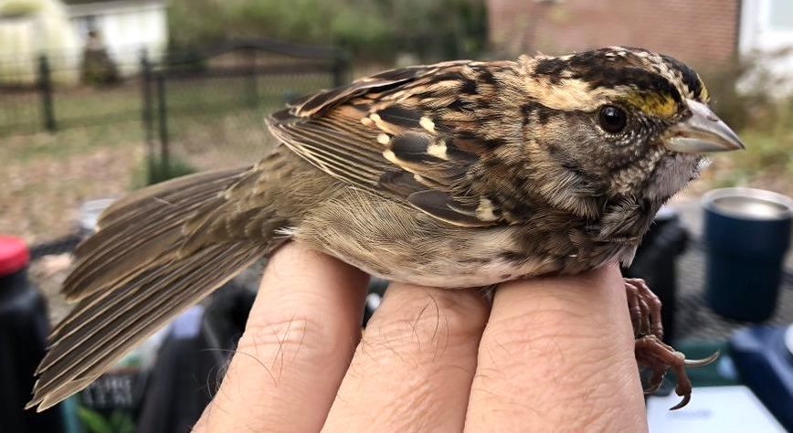

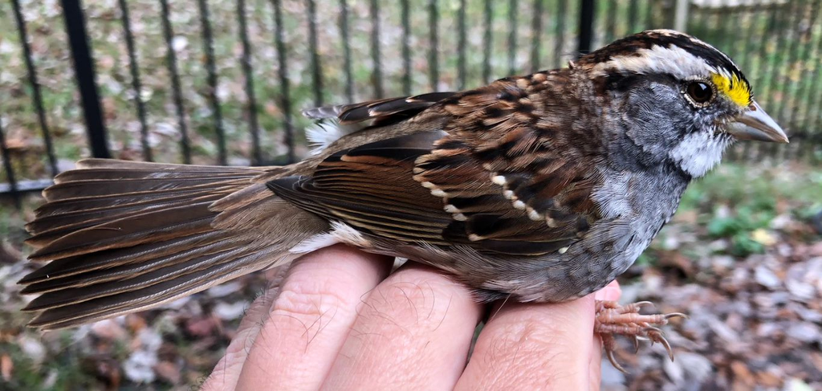

$~$ The white-striped sparrows have been shown to display more aggressive and territorial behaviors, over the tan-striped individuals, including defending food sources like feeders (Kopachena and Falls, 1993). This may imply that white-striped individuals will have a higher fat weight than their more timid tan-striped counterparts.

First, here is a quick look at the raw fit of the data on a binomial graph:

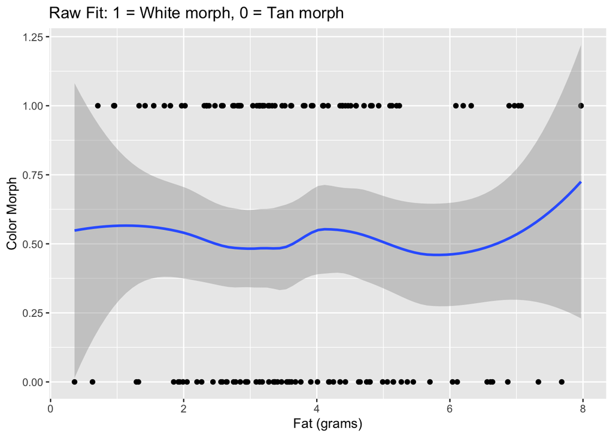

```r
ggplot(WTSPdata, aes(fat, morph)) +
  geom_point() +
  geom_smooth() +
  xlab ("Fat (grams)") +
  ylab ("Color Morph") +
  labs(title="Raw Fit: 1 = White morph, 0 = Tan morph")
```

```r
fit.1 <- glm(morph~fat, data=WTSPdata, binomial(link="logit"))
display(fit.1)
```

```
## glm(formula = morph ~ fat, family = binomial(link = "logit"),
##     data = WTSPdata)
##             coef.est coef.se
## (Intercept)  0.14     0.43
## fat         -0.02     0.10
## ---
##   n = 142, k = 2
##   residual deviance = 196.7, null deviance = 196.7 (difference = 0.0)
```

Using a binned residual plot to verify that the data works in a binomial GLM:

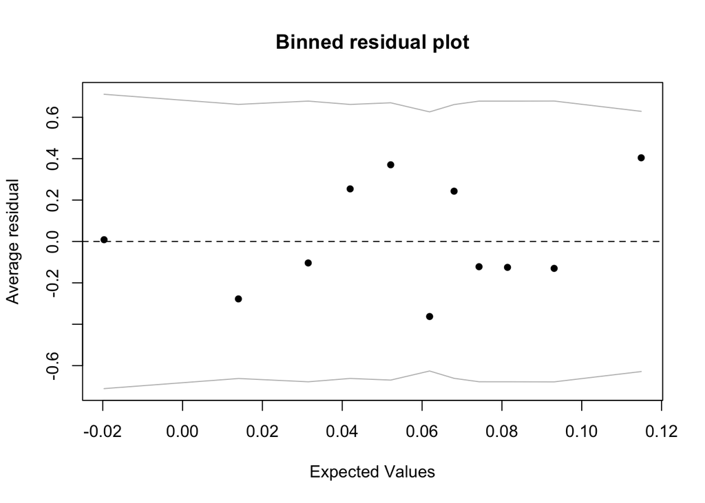

```r
x <- predict(fit.1)
y <- resid(fit.1)
binnedplot(x, y)
```

```r
coef(fit.1)
```

```
## (Intercept)         fat
##  0.14085413 -0.02250686
```

```r
confint(fit.1)
```

```
##                  2.5 %    97.5 %
## (Intercept) -0.6990445 0.9862898
## fat         -0.2296390 0.1837120
```

```r
invlogit <- function(x) {1 / ( 1+exp(-x) ) }
invlogit(coef(fit.1))
```

```
## (Intercept)         fat
##   0.5351554   0.4943735
```

```r
summary(fit.1)
```

```
##
## Call:
## glm(formula = morph ~ fat, family = binomial(link = "logit"),
##     data = WTSPdata)
##
## Deviance Residuals:
##    Min      1Q  Median      3Q     Max
## -1.234  -1.203   1.127   1.151   1.194
##
## Coefficients:
##             Estimate Std. Error z value Pr(>|z|)
## (Intercept)  0.14085    0.42766   0.329    0.742
## fat         -0.02251    0.10474  -0.215    0.830
##
## (Dispersion parameter for binomial family taken to be 1)
##
##     Null deviance: 196.74  on 141  degrees of freedom
## Residual deviance: 196.69  on 140  degrees of freedom
## AIC: 200.69
##
## Number of Fisher Scoring iterations: 3
```

Checking the assumption that the ratio of the residual deviance to the residual DF (dispersion parameter) is approximately 1:1. It is a little higher based on the summary() output table: (196.7/140=1.4)

I used the “family” argument to specify a binomial distribution (for which the logistic is the default link function). The logistic link function and binomial distribution will take account of the properties and constraints on the pattern of the mean and variance for binomial count data.

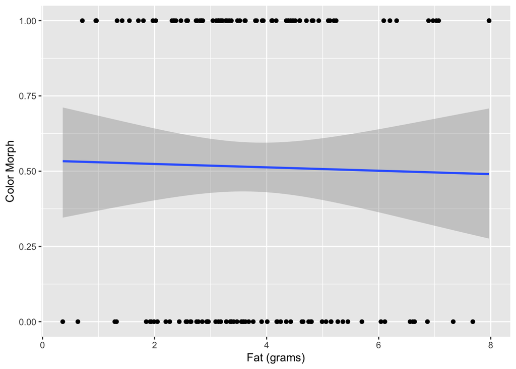

```r
ggplot(WTSPdata, aes(fat, morph)) +
  geom_point() +
  geom_smooth(method="glm", method.args=list(family="binomial"(link="logit"))) +
  xlab ("Fat (grams)") +
  ylab ("Color Morph")
```

$~$  
* In this case, the GLM of the binary White-throated Sparrow data suggests no correlation between color morph on the amount of fat a bird may have.

$~$ $~$

**Grasshopper Sparrow Point-Count Data**

$~$

Herse, Mark R.; With, Kimberly A.; Boyle, W. Alice (2019), Data from: The importance of core habitat for a threatened species in changing landscapes, Dryad, Dataset, [Dataset](https://doi.org/10.5061/dryad.9pr1476)

$~$  
$~$

Grasshopper Sparrows are a grassland-dependent species, requiring large continuous tracts of pristine prairie to thrive. In this data set, point-count surveys were conducted to quantify how many Grasshopper Sparrows were present on variously-sized plots of grassland.

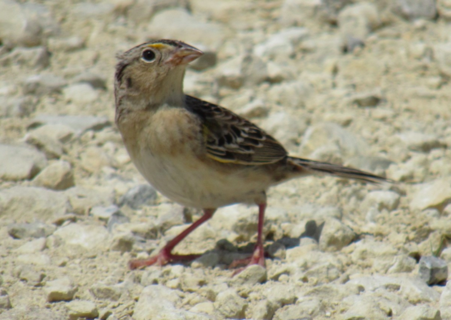

$~$  
A poisson GLM can be used to plot the relationship between the number of birds detected and size of the grassland they’re found on, particualrly with a dataset that contains many zeros (as is the case with many point-count datasets such as this one).

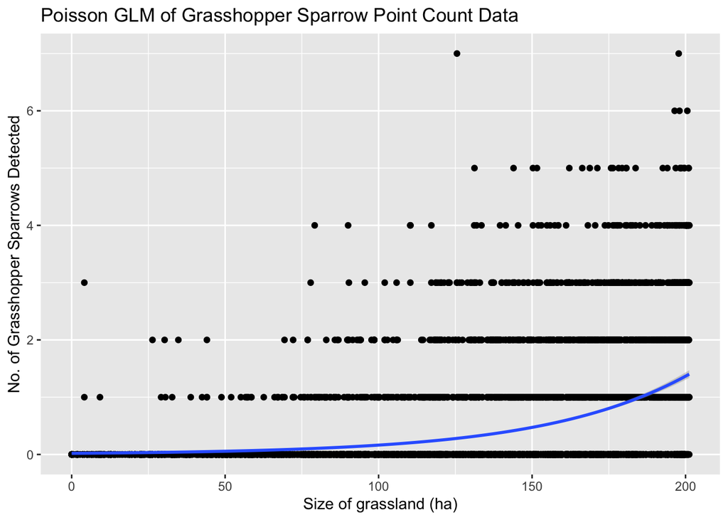

```r
ggplot(GRSPdata, aes(ta_800, grsp)) +
  geom_point() +
  stat_smooth(method = glm, method.args = list(family = poisson(link = "log"))) +
  labs(title="Poisson GLM of Grasshopper Sparrow Point Count Data") +
  xlab ("Size of grassland (ha)") +
  ylab ("No. of Grasshopper Sparrows Detected")
```

```r
grsp.glm <- glm(grsp ~ ta_800, data = GRSPdata, family = poisson(link = log))
anova(grsp.glm)
```

```
## Analysis of Deviance Table
##
## Model: poisson, link: log
##
## Response: grsp
##
## Terms added sequentially (first to last)
##
##
##        Df Deviance Resid. Df Resid. Dev
## NULL                    7229    10045.6
## ta_800  1   2534.4      7228     7511.2
```

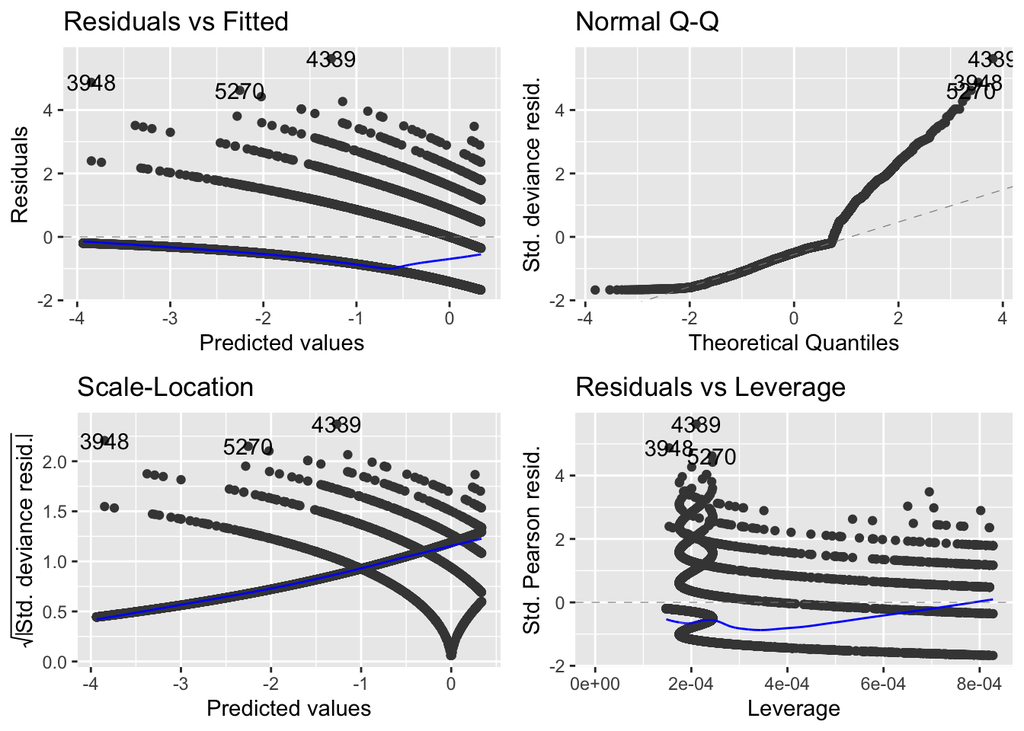

```r
autoplot(grsp.glm)
```

```r
summary(grsp.glm)
```

```
##
## Call:
## glm(formula = grsp ~ ta_800, family = poisson(link = log), data = GRSPdata)
##
## Deviance Residuals:
##     Min       1Q   Median       3Q      Max
## -1.6742  -0.8966  -0.5042  -0.2087   5.6193
##
## Coefficients:
##               Estimate Std. Error z value Pr(>|z|)
## (Intercept) -3.9353640  0.0869924  -45.24   <2e-16 ***
## ta_800       0.0212380  0.0005096   41.68   <2e-16 ***
## ---
## Signif. codes:  0 '***' 0.001 '**' 0.01 '*' 0.05 '.' 0.1 ' ' 1
##
## (Dispersion parameter for poisson family taken to be 1)
##
##     Null deviance: 10045.6  on 7229  degrees of freedom
## Residual deviance:  7511.2  on 7228  degrees of freedom
## AIC: 12072
##
## Number of Fisher Scoring iterations: 6
```

```r
exp(-3.935+0.021*200)
```

```
## [1] 1.303431
```

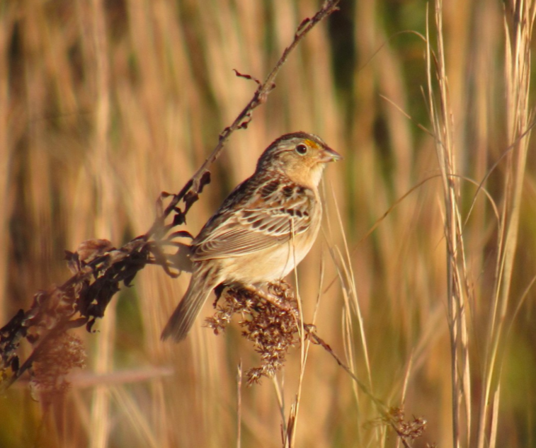

$~$  
$~$